# Correlating HMSC residuals with interaction information

Author

Elena Quintero

Load packages and data

```r
library(here)
library(tidyverse)
library(ggplot2)
library(ggdist)
theme_set(theme_minimal())
```

```r
load(here::here("hmsc/output/cooccurrence_matrix_non_spat.RData"))

ints <- read_csv(here::here("interaction/data/Swiss_web_gen_strict.csv"))
metaweb <- read_csv(here::here("interaction/data/Swiss_metaweb_gen_relaxed.csv"))
preds <- read_csv(here::here("interaction/output/svd_prediction.csv"))
preds_RF <- read_csv(here::here("interaction/output/RF_phylo_model_predictions.csv"))

taxa <- read_csv(here::here("interaction/taxa_list_hmsc.csv"), col_names = FALSE)
butterflies <- taxa$X1[!is.na(taxa$X1)] |> unique()
plants <- taxa$X3[!is.na(taxa$X3)] |> unique()
```

## Relationship between JSDM residuals and species interactions

Load HMSC model residuals.

```r
residuals_mat <- OmegaCor[[1]]$mean

# keep only upper triangle of the matrix
residuals_mat[lower.tri(residuals_mat, diag = TRUE)] <- NA

residuals_long <- residuals_mat |>
    as.data.frame() |>
    rownames_to_column("bf_taxa") |>
    pivot_longer(cols = -bf_taxa, names_to = "pl_taxa", values_to = "residuals") |>
    filter(!is.na(residuals)) |>
    filter(bf_taxa %in% butterflies & pl_taxa %in% plants)
```

Checking matrix dimension

```r
nrow(residuals_long)
```

```
[1] 26895
```

From 163*165 = 26,895 (plant taxa times animal taxa)

Load (1) Swiss interaction data, (2) European metaweb data (potential interactions), and (3) predicted interactiosn; and join with residuals.

```r
ints_long <- ints |>
    rename(pl_taxa = ...1) |>
    pivot_longer(cols = -pl_taxa, names_to = "bf_taxa", values_to = "interaction") |>
    #Change to "Polygonia_c.album" "Satyrium_w.album"
    mutate(bf_taxa = str_replace(bf_taxa, "-", "."))
nrow(ints_long) # more interactions than in residuals df, because some taxa are not in the hmsc model
```

```
[1] 29202
```

```r
# setdiff(unique(ints_long$bf_taxa), unique(residuals_long$bf_taxa))

metaweb_long <- metaweb |>
    rename(pl_taxa = ...1) |>
    pivot_longer(cols = -pl_taxa, names_to = "bf_taxa", values_to = "int_potential") |>
    #Change to "Polygonia_c.album" "Satyrium_w.album"
    mutate(bf_taxa = str_replace(bf_taxa, "-", "."))
nrow(metaweb_long) # Again, more interactions than in residuals df, because some taxa are not in the model
```

```
[1] 77584
```

```r
preds_long <- preds |>
    select(pl_taxa, bf_taxa, int_predicted = Predicted_co)


df <- residuals_long |>
    left_join(ints_long, by = c("bf_taxa", "pl_taxa")) |>
    left_join(metaweb_long, by = c("bf_taxa", "pl_taxa")) |>
    left_join(preds_long, by = c("bf_taxa", "pl_taxa")) |>
    mutate(int_evidence = case_when(
        interaction == 1 ~ "A_recorded",
        int_potential == 1 ~ "B_potential",
        int_predicted == 1 ~ "C_predicted",
        int_potential == 0 ~ "D_absent",
        TRUE ~ NA_character_
    ))
```

Load support matrix and join with the df:

```r
support_mat <- OmegaCor[[1]]$support

# keep only upper triangle of the matrix
support_mat[lower.tri(support_mat, diag = TRUE)] <- NA

support_long <- support_mat |>
    as.data.frame() |>
    rownames_to_column("bf_taxa") |>
    pivot_longer(cols = -bf_taxa, names_to = "pl_taxa", values_to = "support") |>
    filter(!is.na(support)) |>
    filter(bf_taxa %in% butterflies & pl_taxa %in% plants)

df <- df |>
    left_join(support_long, by = c("bf_taxa", "pl_taxa"))
```

Overview of HMSC residuals and support values for the different levels of interaction evidence (recorded, potential, absence):

```r
df |> group_by(int_evidence) |>
    summarise(n = n(),
              mean_residuals = mean(residuals),
              sd_residuals = sd(residuals),
              mean_support = mean(support),
              sd_support = sd(support)) |>
    arrange(desc(mean_residuals))
```

```
# A tibble: 5 × 6
  int_evidence     n mean_residuals sd_residuals mean_support sd_support
  <chr>        <int>          <dbl>        <dbl>        <dbl>      <dbl>
1 A_recorded     324         0.138         0.151        0.837      0.307
2 B_potential    789         0.0936        0.136        0.782      0.319
3 <NA>           165         0.0476        0.177        0.590      0.409
4 C_predicted    882         0.0399        0.158        0.601      0.405
5 D_absent     24735         0.0375        0.158        0.599      0.399
```

**OBS!:** *NA interactions come from the genus Vulpia which is not reported in Clarke (neither in the potential df). Although Vulpia is supposed to be a synonim of Festuca which is indeed recorded in Clarke. So, we have no interaction data for this genus. Removing these NAs from further plots and analyses.*

Distribution plot of residuals for **observed** interactions:

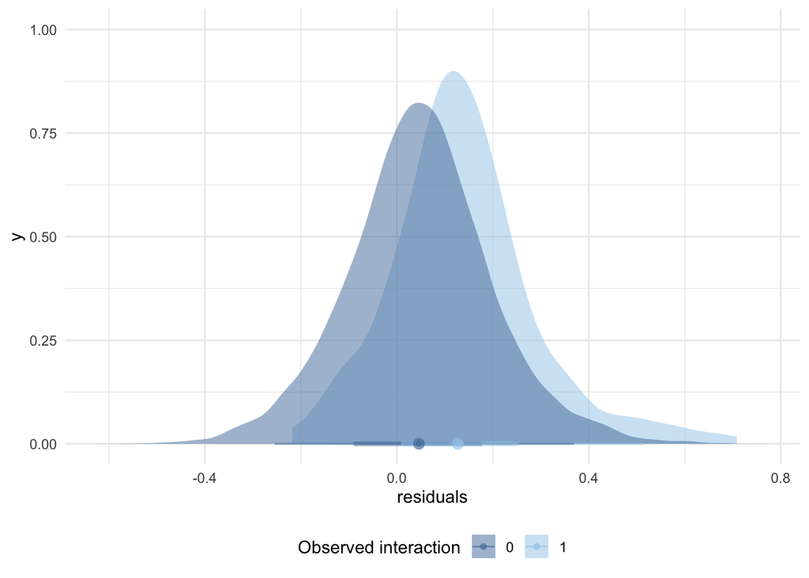

```r
ggplot(df|> filter(!is.na(interaction)),
        aes(x = residuals,
            fill = as.factor(interaction),
            color = as.factor(interaction))) +
    ggdist::stat_halfeye(alpha  = 0.5) +
    paletteer::scale_fill_paletteer_d("ggthemes::Tableau_20") +
    paletteer::scale_color_paletteer_d("ggthemes::Tableau_20") +
    theme(legend.position = "bottom") +
    labs(fill = "Observed interaction", color = "Observed interaction")
```

Distribution plot of residuals **SEPARATING observed and potential** interactions:

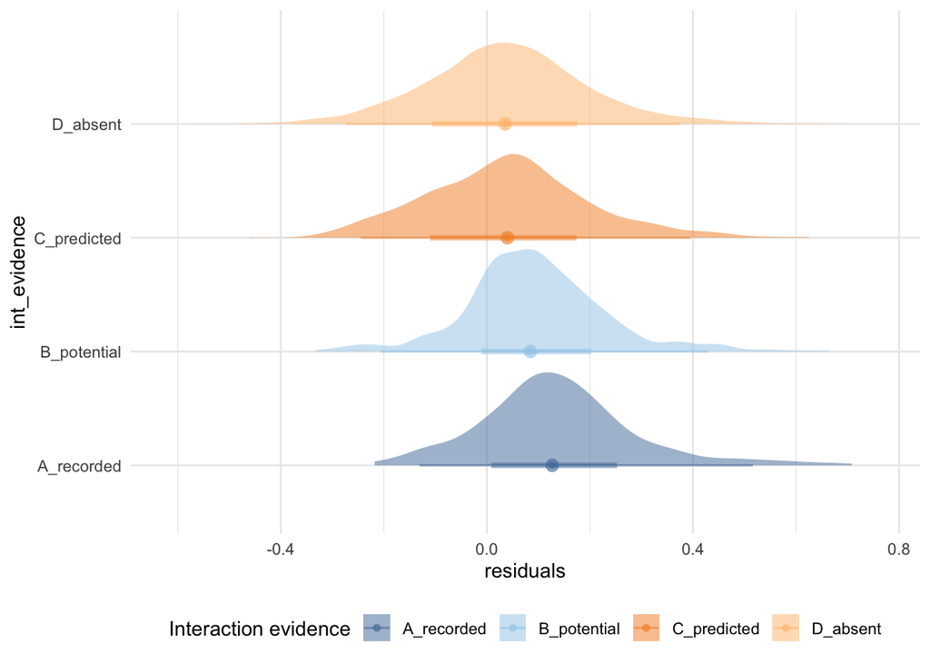

```r
ggplot(df |> filter(!is.na(int_potential)),
        aes(x = residuals, y = int_evidence,
            fill = int_evidence,
            color = int_evidence)) +
    ggdist::stat_halfeye(alpha  = 0.5) +
    paletteer::scale_fill_paletteer_d("ggthemes::Tableau_20") +
    paletteer::scale_color_paletteer_d("ggthemes::Tableau_20") +
    theme(legend.position = "bottom") +
    labs(fill = "Interaction evidence", color = "Interaction evidence")
```

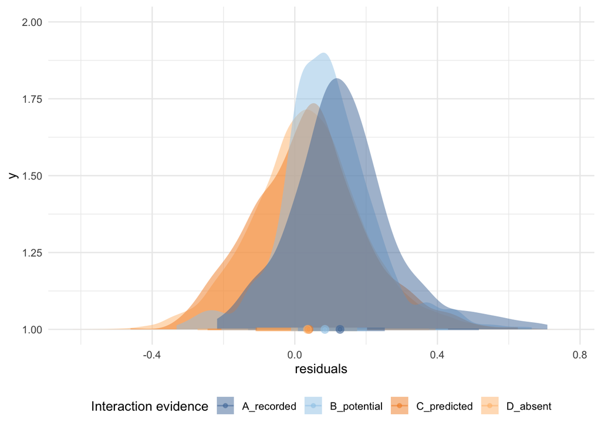

```r
ggplot(df |> filter(!is.na(int_potential)),
        aes(x = residuals, y = 1,
            fill = int_evidence,
            color = int_evidence)) +
    ggdist::stat_halfeye(alpha  = 0.5) +
    paletteer::scale_fill_paletteer_d("ggthemes::Tableau_20") +
    paletteer::scale_color_paletteer_d("ggthemes::Tableau_20") +
    theme(legend.position = "bottom") +
    labs(fill = "Interaction evidence", color = "Interaction evidence")
```

Plot relation of residuals with support for the different level of interaction evidence:

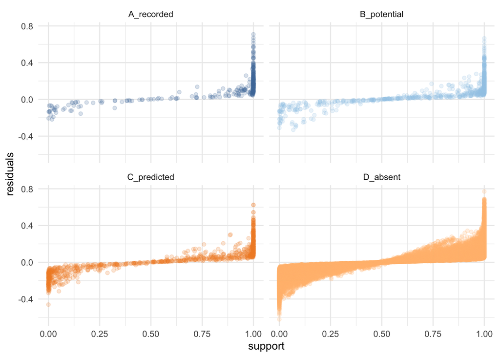

```r
ggplot(df|> filter(!is.na(int_potential)),
           aes(x = support, y = residuals,
               fill = as.factor(int_evidence),
               color = as.factor(int_evidence))) +
    geom_point(alpha = 0.2) +
    facet_wrap(~int_evidence) +
    theme_minimal() +
    paletteer::scale_fill_paletteer_d("ggthemes::Tableau_20") +
    paletteer::scale_color_paletteer_d("ggthemes::Tableau_20") +
    theme(legend.position = "none")
```

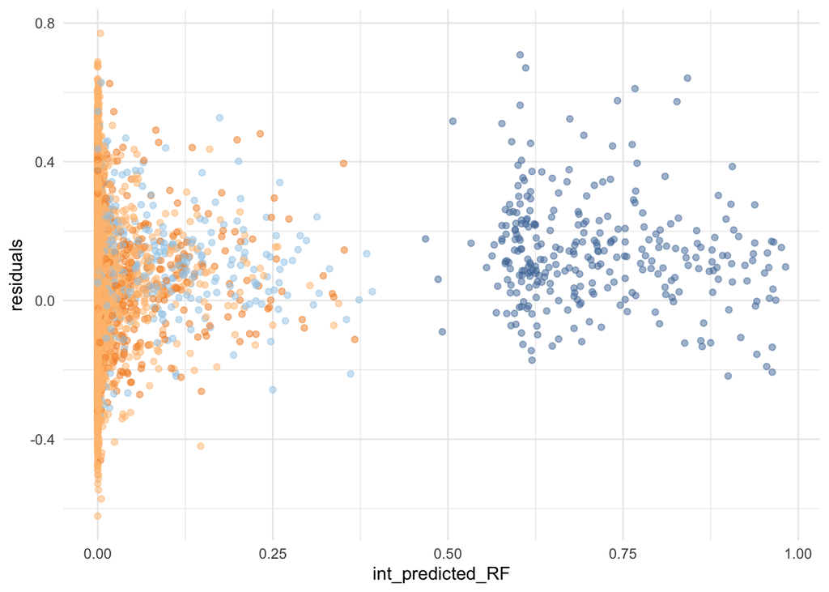

```r
df <- df |> left_join(preds_RF |> select(butterfly, plant, int_predicted_RF = predicted_prob), by = c("bf_taxa" = "butterfly", "pl_taxa" = "plant"))

p1 <- ggplot(df |> filter(!is.na(int_predicted_RF)),
           aes(x = int_predicted_RF, y = residuals,
               fill = as.factor(int_evidence),
               color = as.factor(int_evidence))) +
    geom_point(alpha = 0.5) +
    theme_minimal() +
    paletteer::scale_fill_paletteer_d("ggthemes::Tableau_20") +
    paletteer::scale_color_paletteer_d("ggthemes::Tableau_20") +
    theme(legend.position = "none")

p1
```

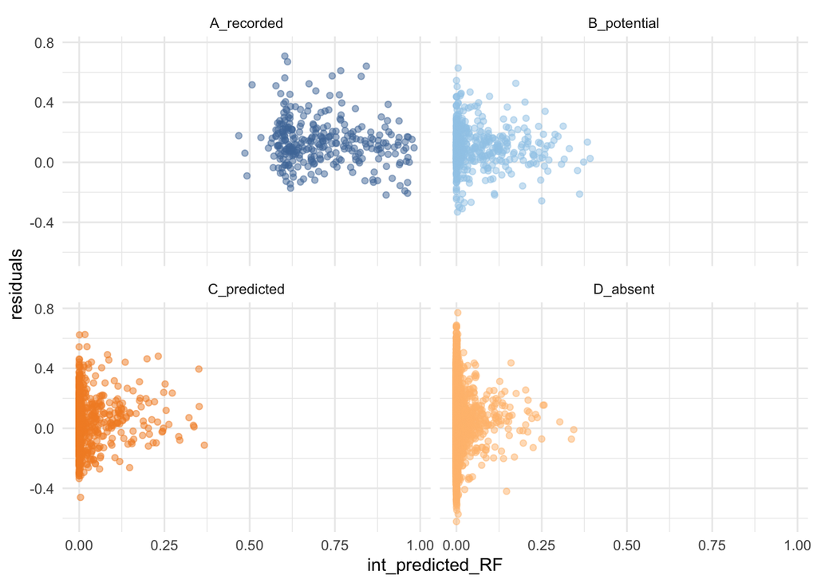

```r
p1 + facet_wrap(~int_evidence)
```

## Model for testing interaction effect on residuals

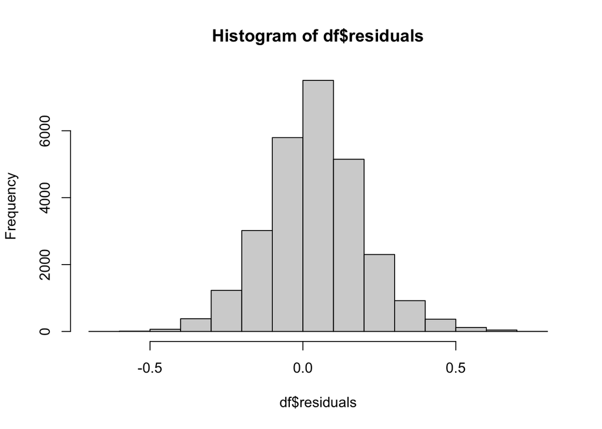

```r
# hist(df$interaction)
# hist(df$int_potential)
# hist(df$residuals)
# hist(df$support)

library(glmmTMB)

hist(df$residuals)
```

```r
m1 <- glmmTMB(residuals ~ int_evidence + (1 | bf_taxa) + (1 | pl_taxa), family = gaussian, data = df)
summary(m1)
```

```
 Family: gaussian  ( identity )
Formula:          residuals ~ int_evidence + (1 | bf_taxa) + (1 | pl_taxa)
Data: df

      AIC       BIC    logLik -2*log(L)  df.resid
 -34856.9  -34799.6   17435.5  -34870.9     26723

Random effects:

Conditional model:
 Groups   Name        Variance Std.Dev.
 bf_taxa  (Intercept) 0.008006 0.08947
 pl_taxa  (Intercept) 0.001576 0.03969
 Residual             0.015185 0.12323
Number of obs: 26730, groups:  bf_taxa, 165; pl_taxa, 162

Dispersion estimate for gaussian family (sigma^2): 0.0152

Conditional model:
                         Estimate Std. Error z value Pr(>|z|)
(Intercept)              0.135328   0.010351  13.074  < 2e-16 ***
int_evidenceB_potential -0.051668   0.008274  -6.244 4.25e-10 ***
int_evidenceC_predicted -0.090900   0.008161 -11.139  < 2e-16 ***
int_evidenceD_absent    -0.097628   0.007045 -13.857  < 2e-16 ***
---
Signif. codes:  0 '***' 0.001 '**' 0.01 '*' 0.05 '.' 0.1 ' ' 1
```

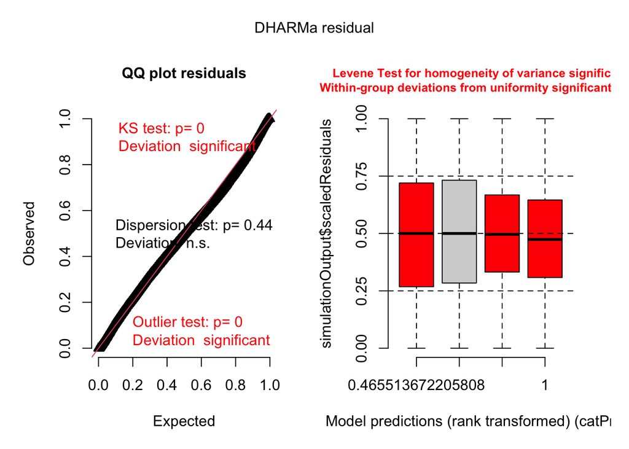

```
Object of Class DHARMa with simulated residuals based on 250 simulations with refit = FALSE . See ?DHARMa::simulateResiduals for help.

Scaled residual values: 0.676 0.048 0.208 0.66 0.96 0.804 0.7 0.372 0.308 0.628 0.432 0.656 0.872 0.192 0.084 0.036 0.024 0.508 0.68 0.544 ...
```

```r
# performance::check_model(m1)
DHARMa::simulateResiduals(m1, plot = TRUE)
```

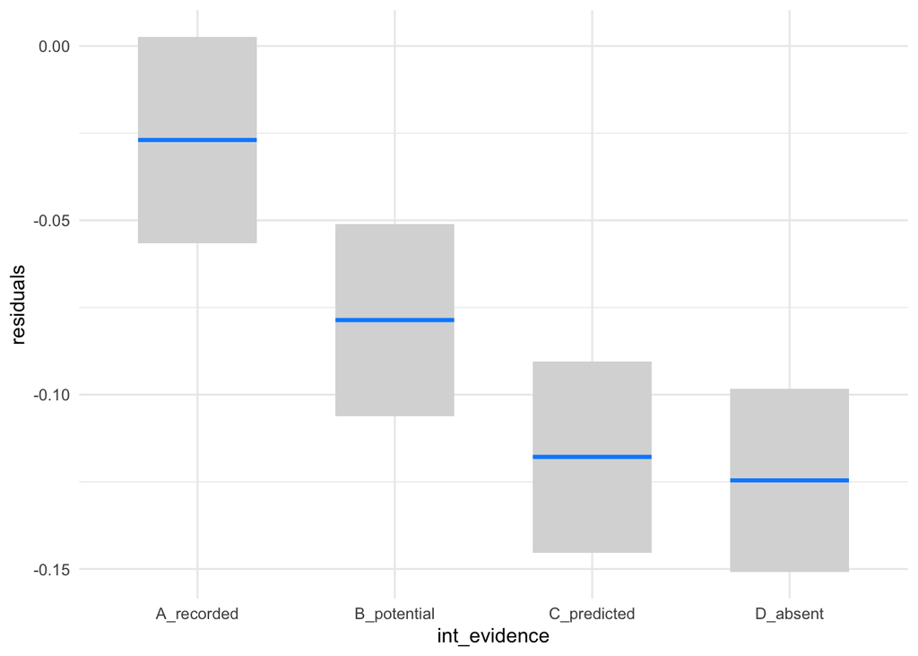

```r
visreg::visreg(m1, "int_evidence", scale = "response", gg = TRUE) + theme_minimal()
```

```r
emmeans::emmeans(m1, pairwise ~ int_evidence)
```

```
$emmeans
 int_evidence emmean      SE  df asymp.LCL asymp.UCL
 A_recorded   0.1353 0.01040 Inf    0.1150    0.1556
 B_potential  0.0837 0.00889 Inf    0.0662    0.1011
 C_predicted  0.0444 0.00878 Inf    0.0272    0.0616
 D_absent     0.0377 0.00767 Inf    0.0227    0.0527

Confidence level used: 0.95

$contrasts
 contrast                  estimate      SE  df z.ratio p.value
 A_recorded - B_potential   0.05167 0.00827 Inf   6.244 <0.0001
 A_recorded - C_predicted   0.09090 0.00816 Inf  11.139 <0.0001
 A_recorded - D_absent      0.09763 0.00705 Inf  13.857 <0.0001
 B_potential - C_predicted  0.03923 0.00624 Inf   6.288 <0.0001
 B_potential - D_absent     0.04596 0.00464 Inf   9.912 <0.0001
 C_predicted - D_absent     0.00673 0.00442 Inf   1.523  0.4238

P value adjustment: tukey method for comparing a family of 4 estimates
```

```r
performance::r2_nakagawa(m1)
```

```
# R2 for Mixed Models

  Conditional R2: 0.391
     Marginal R2: 0.007
```

```r
# insight::get_variance(m1)
```

There seems to be a clear positive effect of the interaction on the residuals, with recorded interactions having higher residuals than potential interactions and absences. Interaction evidence explains 0.7% of the variation in JSDM residual associations, including animal and plant taxon identity increased the explained variance to 39.1%.

**Alternative model: adding support as a predictor**

Weird residual distribution.

```r
m2 <- glmmTMB(residuals ~ int_evidence + support + (1 | bf_taxa) + (1 | pl_taxa), family = gaussian, data = df)
summary(m2)
```

```
 Family: gaussian  ( identity )
Formula:
residuals ~ int_evidence + support + (1 | bf_taxa) + (1 | pl_taxa)
Data: df

      AIC       BIC    logLik -2*log(L)  df.resid
 -63528.8  -63463.2   31772.4  -63544.8     26722

Random effects:

Conditional model:
 Groups   Name        Variance  Std.Dev.
 bf_taxa  (Intercept) 0.0012370 0.03517
 pl_taxa  (Intercept) 0.0005054 0.02248
 Residual             0.0052219 0.07226
Number of obs: 26730, groups:  bf_taxa, 165; pl_taxa, 162

Dispersion estimate for gaussian family (sigma^2): 0.00522

Conditional model:
                         Estimate Std. Error z value Pr(>|z|)
(Intercept)             -0.110237   0.005349  -20.61  < 2e-16 ***
int_evidenceB_potential -0.027044   0.004852   -5.57 2.50e-08 ***
int_evidenceC_predicted -0.031687   0.004792   -6.61 3.79e-11 ***
int_evidenceD_absent    -0.037983   0.004140   -9.18  < 2e-16 ***
support                  0.309086   0.001365  226.36  < 2e-16 ***
---
Signif. codes:  0 '***' 0.001 '**' 0.01 '*' 0.05 '.' 0.1 ' ' 1
```

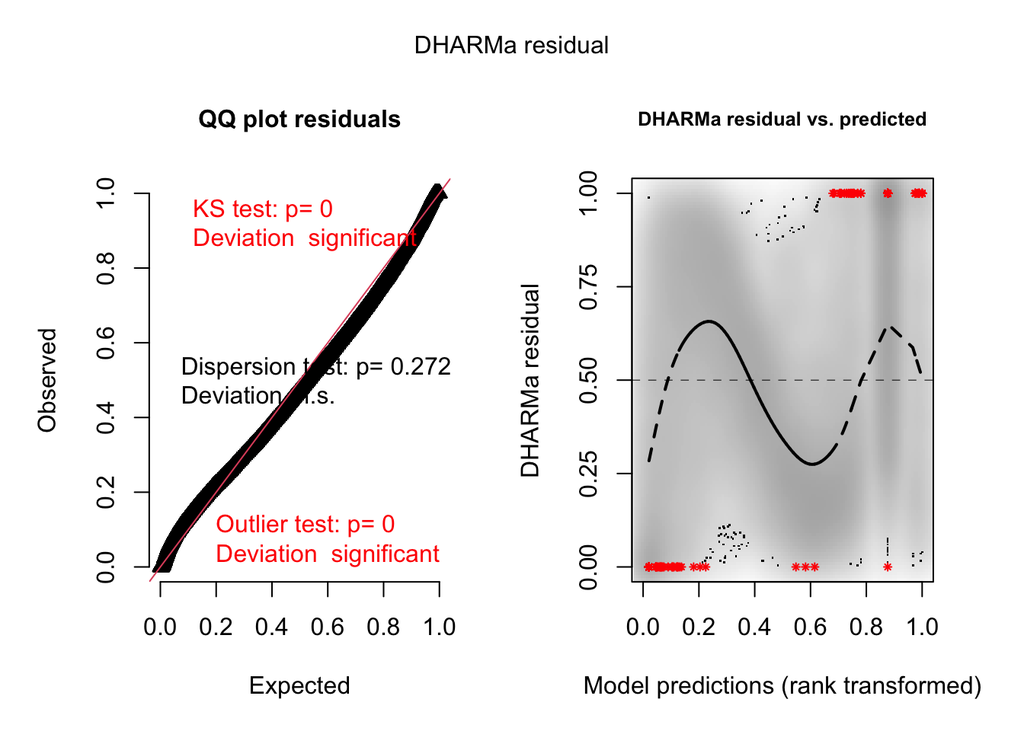

```
Object of Class DHARMa with simulated residuals based on 250 simulations with refit = FALSE . See ?DHARMa::simulateResiduals for help.

Scaled residual values: 0.924 0.008 0.04 0.816 0.264 0.908 0.896 0.596 0.188 0.816 0.208 0.932 0.644 0.368 0.024 0.028 0.004 0.676 0.792 0.704 ...
```

```r
DHARMa::simulateResiduals(m2, plot = TRUE)
```

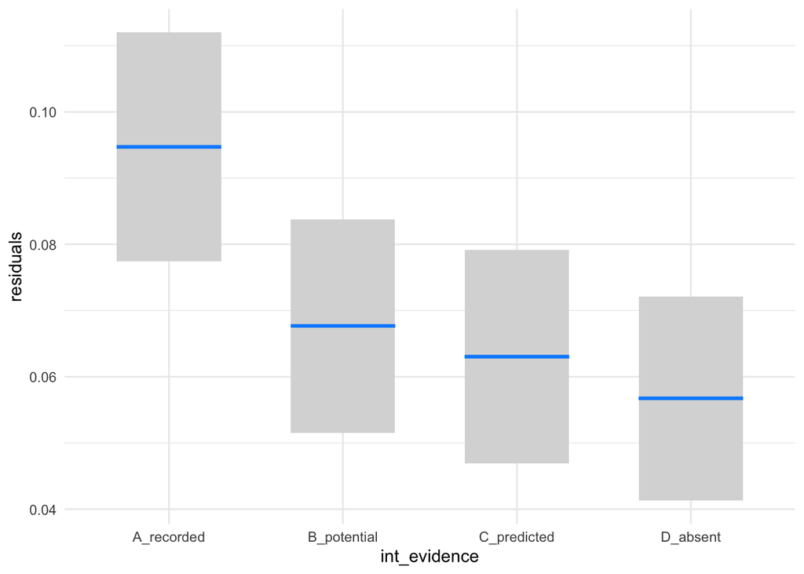

```r
visreg::visreg(m2, "int_evidence", scale = "response", gg = TRUE) + theme_minimal()
```

```r
emmeans::emmeans(m2, pairwise ~ int_evidence)
```

```
$emmeans
 int_evidence emmean      SE  df asymp.LCL asymp.UCL
 A_recorded   0.0775 0.00524 Inf    0.0672    0.0877
 B_potential  0.0504 0.00422 Inf    0.0421    0.0587
 C_predicted  0.0458 0.00413 Inf    0.0377    0.0539
 D_absent     0.0395 0.00329 Inf    0.0330    0.0459

Confidence level used: 0.95

$contrasts
 contrast                  estimate      SE  df z.ratio p.value
 A_recorded - B_potential   0.02704 0.00485 Inf   5.573 <0.0001
 A_recorded - C_predicted   0.03169 0.00479 Inf   6.612 <0.0001
 A_recorded - D_absent      0.03798 0.00414 Inf   9.175 <0.0001
 B_potential - C_predicted  0.00464 0.00366 Inf   1.269  0.5830
 B_potential - D_absent     0.01094 0.00272 Inf   4.017  0.0003
 C_predicted - D_absent     0.00630 0.00259 Inf   2.431  0.0714

P value adjustment: tukey method for comparing a family of 4 estimates
```

```r
performance::r2_nakagawa(m2)
```

```
# R2 for Mixed Models

  Conditional R2: 0.765
     Marginal R2: 0.687
```

If we had posterior distributions from the JSDM rather than just one residual value per animal–plant pair, we could build a better model considering uncertainty.

To be continued…